# Industry 4.0 의 중심, AI - ML&DL

Machine Learning & Deep Learning with TensorFlow @ [FB / jskim.kr](https://www.facebook.com/jskim.kr), 김진수

## Tensorflow Programming Model

> https://developers.google.com/codelabs/tensorflow-1-helloworld
> - Before start...
> - ML이란?
> - 첫 ML 모델 만들기
> - 신경망 학습시키기
> - 모델 사용
> - Congratulation

```python
from images import bigpycraft_dl as bpc
from IPython.display import Image
```

### Introduction - Activity Recognintion

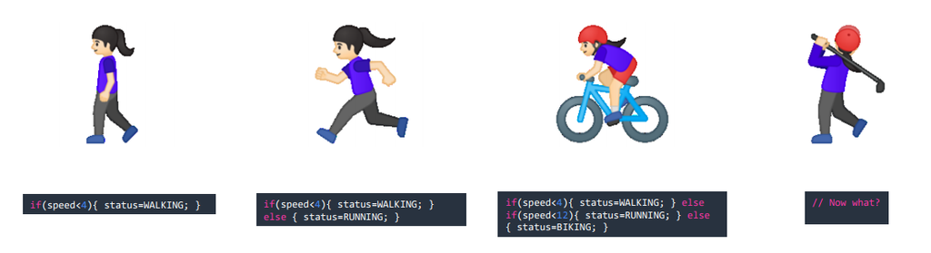

```python
Image(bpc.DL01_IMG_01)
```

### Understanding ML(=Machine Learning)

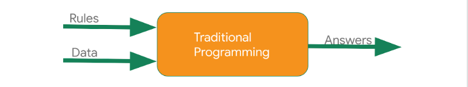

```python
# Rule-based Programming
Image(bpc.DL01_IMG_02)
```

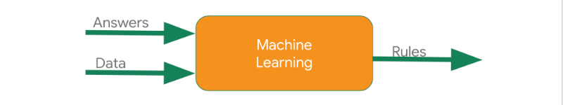

```python
# ML-based Programming
Image(bpc.DL01_IMG_03)
```

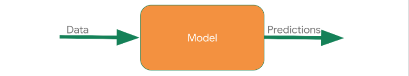

```python
# ML-Model Predictions
Image(bpc.DL01_IMG_04)
```

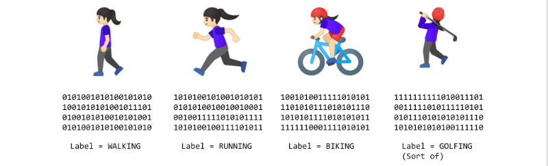

```python
# ML-Context
Image(bpc.DL01_IMG_05)
```

### ML Model

| X | -1 | 0 | 1 | 2 | 3 | 4 |
| --- | --- | --- | --- | --- | --- | --- |
| Y | -2 | 1 | 4 | 7 | 10 | 13 |

$$Y = 3X + 1$$

```python
import tensorflow as tf
import numpy as np
from tensorflow import keras
```

```python
tf.__version__
```

```
'2.9.1'
```

### 신경망 정의 및 컴파일

> - 가장 간단한 신경망을 만듭니다. 레이어가 하나이고, 레이어에 뉴런이 하나 있으며, 입력 도형은 값이 하나뿐입니다.

```python
model = tf.keras.Sequential([keras.layers.Dense(units=1, input_shape=[1])])
```

> - 그런 다음 신경망을 컴파일하는 코드를 작성합니다. 이렇게 하려면 loss와 optimizer을 두 가지 함수로 지정해야 합니다.
> - 먼저 손실에 mean_squared_error를 사용하고 옵티마이저에 스토크 경사하강법(sgd)을 사용하도록 지시하는 방법을 알아보겠습니다

```python
model.compile(optimizer='sgd', loss='mean_squared_error')
```

### 데이터 제공

> - NumPy라는 Python 라이브러리는 이를 위한 다양한 배열 유형 데이터 구조를 제공합니다.
> - np.array[]를 사용하여 NumPy의 배열로 값을 지정합니다.

```python
xs = np.array([-1.0, 0.0, 1.0, 2.0, 3.0, 4.0], dtype=float)
ys = np.array([-2.0, 1.0, 4.0, 7.0, 10.0, 13.0], dtype=float)
```

### 신경망 학습

```python
model.fit(xs, ys, epochs=500)
```

```
<keras.callbacks.History at 0x25c4e87df10>
```

### 모델 사용

> - X와 Y의 관계를 학습하도록 학습된 모델이 있습니다.
> - model.predict 메서드를 사용하여 이전에 알려지지 않은 X의 Y를 파악할 수 있습니다.
> - 예를 들어 X가 10이라면 Y는 어떻게 될까요? 다음 코드를 실행하기 전에 추측해 보세요.

```python
print(model.predict([10.0]))
```

```
[[31.001608]]
```

```python
int(model.predict([10.0]))
```

```
31
```

```python
np.floor(model.predict([10.0]))
```

```
array([[31.]], dtype=float32)
```

```python
print(format(float(model.predict([10.0])), '.2f'))
```

```
31.00
```

The BigpyCraft find the information to design valuable society with Technology & Craft.

< The End >